# Exploring the Latest Changes in the CBRT Policy Rate Using EVDS R

Utkuhan Genc

June 13, 2018

This brief analysis examines the latest monetary policies of the Central Bank of the Republic of Turkey. The data that was used in this analysis can be seen at the [official database for CBRT.](https://evds2.tcmb.gov.tr/index.php?/evds/serieMarket) To get the data from this website, I used [EVDS R package created by Algopoly.](https://github.com/algopoly/EVDS)

## How to install EVDS R package?

To install the EVDS package I used in this analysis, you can use devtools to download it. After downloading this package you also need to sign up at EVDS website to get your distinct API Key. This key will help you get any data you want from the database, by using the package.

```r
devtools::install_github("algopoly/EVDS")
```

We need to use some packages to get and to analyze the data. **If these packages are not already installed please install them before starting.**

```r
library(tidyverse)
library(EVDS)
library(lubridate)
library(zoo)
```

We start by setting our API key. You can get your API key from [EVDS website](https://evds2.tcmb.gov.tr/), from your profile page.

```r
set_evds_key("YOURAPIKEY")
```

## Preparing Data

By using `get_series` function we can get the data we want from the EVDS website. As seen below, the function takes 3 arguments: Series names, start date and end date. All dates should be in `dd-mm-YYYY` format.

**TP.PY.P02.LON** is used to get the “(LON) TCMB Kotasyonlari SATIS (%)(Geç Likidite Penceresi) - Düzey” which corresponds “the late liquidity window interest rates” . Another variable in our series argument is **TP.APIFON4** is used to get the “TCMB Agirlikli Ortalama Fonlama Maliyeti - Düzey” which corresponds “CBRT’s weighted average funding cost”. **TP.DK.USD.A** is the currency exchange rate between USD and TL. **TP.DK.EUR.A** is the currency exchange rate between EUR and TL. The start date and end date lets me pick whenever time I want to get these values from. One thing to mention is that **TP.APIFON4** is not the exact policy interest rate value because such value does not exist in EVDS website. (ps. I double checked with EVDS team about this and they directed me to the [CBRT website for corresponding table.](http://www.tcmb.gov.tr/wps/wcm/connect/TR/TCMB+TR/Main+Menu/Temel+Faaliyetler/Para+Politikasi/Merkez+Bankasi+Faiz+Oranlari/1+Hafta+Repo)) The CBRT’s weighted average funding cost (TCMB agirlikli ortalama fonlama maliyeti) is the data I used in this case. This data takes the average of the policy interest rate and the late liquidity window interest rate. Furthermore I used the policy interest rate data from TCMB’s website by manually creating a csv file. I also performed some cleaning on the data. First, I transformed the data from list to data frame so it will be easier to work with. Also I changed dates from character to date so we can graph the data. Aside from that, I renamed the variable names to make it easier to distinguish them. Finally, I combined everything in one data set and do my analysis on this data set.

```r
# Get data on some series
df <- get_series(series = c("TP.PY.P02.LON","TP.APIFON4", "TP.DK.USD.A","TP.DK.EUR.A"),start_date = "01-01-2011", end_date = "11-06-2018")

#Creating a date frame for policy interest rate
policy <- read.csv("interest.csv")  %>%
  mutate(Date = dmy(Tarih))

#Constructing a new table with Policy Interest Rate
df1 <- df$items %>%
  select(-UNIXTIME)%>%
  na.omit() %>%
  mutate(Date = dmy(Tarih), Late_Liqudity_Interest_Rate = TP_PY_P02_LON, Weighted_Average_Funding_Cost = TP_APIFON4, Dollar_Rate = TP_DK_USD_A, Euro_Rate = TP_DK_EUR_A)

df2 <- left_join(df1, policy, by = "Date") %>% mutate(Policy_Interest_Rate = na.locf(Policy_Interest_Rate,na.rm = FALSE))
```

## Plots

```r
df3 <-
df2 %>%
  select(Late_Liqudity_Interest_Rate, Weighted_Average_Funding_Cost, Date, Dollar_Rate, Euro_Rate, Policy_Interest_Rate) %>%
  gather(key=serie,value = value,-Date) %>%
  mutate(rate_type=ifelse(serie %in% c("Dollar_Rate","Euro_Rate"),"Currency Exchange Rate","Interest Rate")) %>%
  tbl_df()
```

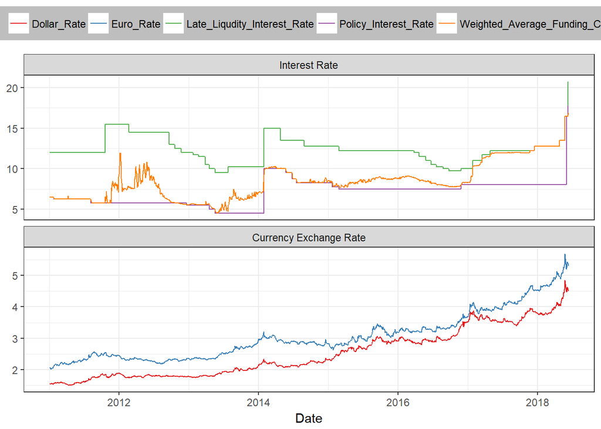

```r
ggplot(df3, aes(x=Date,y=value,color=serie)) +
  geom_line() +
  facet_wrap(~factor(rate_type,levels=c("Interest Rate","Currency Exchange Rate")), scales = "free_y", dir  = "v") +
  theme_bw()+
  theme(legend.position="top" , legend.background = element_rect(fill="gray", linetype="solid")) +
  labs(y=NULL) +
  scale_color_brewer("", palette = "Set1")
```

## Analysis

Another big jump on policy interest rate and the late liqudity window interest rate is because the recent increase of interest rates by CBRT. This action was taken to make sure to stabilize the Turkish Lira’s value however as it can be seen from the graph this action was taken so late. Even though the currency rates were increasing in a fast pace, CBRT waited for so long to take action. That’s why there is only a small change in currency rates.

However, further research has to be done on this topic. Also the correlation between the late liqudity window interest rate and the weighted average funding cost is another interesting relationship to look at. There seems to be a positive correlation between those two values. Another interesting thing to point out is the latest late liqudity window interest rate announced by CBRT on June 8th 2018 is as high as 20.75 which is the highest value since 2009.

## About the author

I am working as a Data Analyst Intern for Algopoly, also I am a student studying Industrial Engineering, Applied Statistics, and Economics at Purdue University, US. I have an incredible passion for using analytical and intercultural communication skills to solve cross-cultural problems in the business world. I am also working as an NBA Data Analyst Intern for Trendbasket. I use my skills to engage basketball fans in Turkey. For more information check my [Linkedin profile](https://www.linkedin.com/in/utkuhangenc/).